# Project: Investigate a Dataset - [No_show_appointment]

- Introduction
- Data Wrangling
- Exploratory Data Analysis
- Conclusions

## Introduction

### Dataset Description

> This dataset collects information from 100k medical appointments in Brazil and is focused on the question of whether or not patients show up for their appointment. A number of characteristics about the patient are included in each row. ‘ScheduledDay’ tells us on what day the patient set up their appointment. ‘Neighborhood’ indicates the location of the hospital. ‘Scholarship’ indicates whether or not the patient is enrolled in Brasilian welfare program Bolsa Família.

### Question(s) for Analysis

> **Question 1**: What's the distribution of Age and gender for the keeping up to scheduled appointment.

> **Question 2:** Which of the the neighbourhoud has the highest keeping to appointment and the neighbourhood with highest missed appointment.

> **Question 3:** Which sickness are predominant in people missing or keeping up with appointment.

> **Question 4:** What factors are important for us to know in order to predict if a patient will show up for their scheduled appointment (x = scholarship, sms. y = No-show-appointment?

```python
# Importing packages to our project

import pandas as pd
import matplotlib.pyplot as plt
import seaborn as sns
import numpy as np

%matplotlib inline
```

## Data Wrangling

```python
#loading dataset

df_app = pd.read_csv("noshowappointments-kagglev2-may-2016.csv")
df_app.head()
```

|  | PatientId | AppointmentID | Gender | ScheduledDay | AppointmentDay | Age | Neighbourhood | Scholarship | Hipertension | Diabetes | Alcoholism | Handcap | SMS_received | No-show |
| --- | --- | --- | --- | --- | --- | --- | --- | --- | --- | --- | --- | --- | --- | --- |
| 0 | 2.987250e+13 | 5642903 | F | 2016-04-29T18:38:08Z | 2016-04-29T00:00:00Z | 62 | JARDIM DA PENHA | 0 | 1 | 0 | 0 | 0 | 0 | No |
| 1 | 5.589978e+14 | 5642503 | M | 2016-04-29T16:08:27Z | 2016-04-29T00:00:00Z | 56 | JARDIM DA PENHA | 0 | 0 | 0 | 0 | 0 | 0 | No |
| 2 | 4.262962e+12 | 5642549 | F | 2016-04-29T16:19:04Z | 2016-04-29T00:00:00Z | 62 | MATA DA PRAIA | 0 | 0 | 0 | 0 | 0 | 0 | No |
| 3 | 8.679512e+11 | 5642828 | F | 2016-04-29T17:29:31Z | 2016-04-29T00:00:00Z | 8 | PONTAL DE CAMBURI | 0 | 0 | 0 | 0 | 0 | 0 | No |
| 4 | 8.841186e+12 | 5642494 | F | 2016-04-29T16:07:23Z | 2016-04-29T00:00:00Z | 56 | JARDIM DA PENHA | 0 | 1 | 1 | 0 | 0 | 0 | No |

We have successfully loaded our noshowappointments dataset and previewed. To avoid confusion, we would rename our **No-show** column to **show** and **NO** to **YES** to avoid confusion during our stage of analysis.

```python
# checking to see the number of rows and columns in the dataset.
df_app.shape
```

```
(110527, 14)
```

There are 110527 rows and 14 columns in the dataset.

```python
# checking info to see the dataset in details
df_app.info()
```

```
<class 'pandas.core.frame.DataFrame'>
RangeIndex: 110527 entries, 0 to 110526
Data columns (total 14 columns):
PatientId         110527 non-null float64
AppointmentID     110527 non-null int64
Gender            110527 non-null object
ScheduledDay      110527 non-null object
AppointmentDay    110527 non-null object
Age               110527 non-null int64
Neighbourhood     110527 non-null object
Scholarship       110527 non-null int64
Hipertension      110527 non-null int64
Diabetes          110527 non-null int64
Alcoholism        110527 non-null int64
Handcap           110527 non-null int64
SMS_received      110527 non-null int64
No-show           110527 non-null object
dtypes: float64(1), int64(8), object(5)
memory usage: 11.8+ MB
```

There are no missing cells in the dataset as shown above. we can further confirm that in the code cell below.

```python
df_app.isna().any().sum()
```

```
0
```

```python
df_app.describe()
```

|  | PatientId | AppointmentID | Age | Scholarship | Hipertension | Diabetes | Alcoholism | Handcap | SMS_received |
| --- | --- | --- | --- | --- | --- | --- | --- | --- | --- |
| count | 1.105270e+05 | 1.105270e+05 | 110527.000000 | 110527.000000 | 110527.000000 | 110527.000000 | 110527.000000 | 110527.000000 | 110527.000000 |
| mean | 1.474963e+14 | 5.675305e+06 | 37.088874 | 0.098266 | 0.197246 | 0.071865 | 0.030400 | 0.022248 | 0.321026 |
| std | 2.560949e+14 | 7.129575e+04 | 23.110205 | 0.297675 | 0.397921 | 0.258265 | 0.171686 | 0.161543 | 0.466873 |
| min | 3.921784e+04 | 5.030230e+06 | -1.000000 | 0.000000 | 0.000000 | 0.000000 | 0.000000 | 0.000000 | 0.000000 |
| 25% | 4.172614e+12 | 5.640286e+06 | 18.000000 | 0.000000 | 0.000000 | 0.000000 | 0.000000 | 0.000000 | 0.000000 |
| 50% | 3.173184e+13 | 5.680573e+06 | 37.000000 | 0.000000 | 0.000000 | 0.000000 | 0.000000 | 0.000000 | 0.000000 |
| 75% | 9.439172e+13 | 5.725524e+06 | 55.000000 | 0.000000 | 0.000000 | 0.000000 | 0.000000 | 0.000000 | 1.000000 |
| max | 9.999816e+14 | 5.790484e+06 | 115.000000 | 1.000000 | 1.000000 | 1.000000 | 1.000000 | 4.000000 | 1.000000 |

Observe we have minimum age to be **(-1)** which is not ideal, we have to clean this up in the datacleaning process.

```python
# checking the datatype of our dataset

df_app.dtypes
```

```
PatientId         float64
AppointmentID       int64
Gender             object
ScheduledDay       object
AppointmentDay     object
Age                 int64
Neighbourhood      object
Scholarship         int64
Hipertension        int64
Diabetes            int64
Alcoholism          int64
Handcap             int64
SMS_received        int64
No-show            object
dtype: object
```

### Data Cleaning

> We observed previously there are some cleaning that would be done on our data to tidy it up. looking at the mismatched data type for **ScheduledDay** and **AppointmentDay**, mis-typed age as -1, changing no-show column and feature values to SHOW and values, from NO : YES and then YES = 1 AND NO = 0 for further exploration.

```python
# cleaning mismatched datatypes in ScheduledDay and AppointmentDay, to datatime.
df_app["AppointmentDay"] = pd.to_datetime(df_app["AppointmentDay"])
df_app["ScheduledDay"] = pd.to_datetime(df_app["ScheduledDay"])
```

let's confirm to see if its been implemented.

```python
df_app.dtypes
```

```
PatientId                float64
AppointmentID              int64
Gender                    object
ScheduledDay      datetime64[ns]
AppointmentDay    datetime64[ns]
Age                        int64
Neighbourhood             object
Scholarship                int64
Hipertension               int64
Diabetes                   int64
Alcoholism                 int64
Handcap                    int64
SMS_received               int64
No-show                   object
dtype: object
```

lets proceed to dropping the feature with age -1. As published by [Research gate Destribution of Age](https://www.researchgate.net/figure/Age-intervals-and-age-groups_tbl1_228404297). Age of -1 doesn't meet any standard.

```python
df_app.query("Age == -1")
```

|  | PatientId | AppointmentID | Gender | ScheduledDay | AppointmentDay | Age | Neighbourhood | Scholarship | Hipertension | Diabetes | Alcoholism | Handcap | SMS_received | No-show |
| --- | --- | --- | --- | --- | --- | --- | --- | --- | --- | --- | --- | --- | --- | --- |
| 99832 | 4.659432e+14 | 5775010 | F | 2016-06-06 08:58:13 | 2016-06-06 | -1 | ROMÃO | 0 | 0 | 0 | 0 | 0 | 0 | No |

```python
df_app.drop(index=99832,inplace=True) # Dropping the row containing the -1 age.
```

Let's confirm again

```python
df_app.query("Age == -1")
```

|  | PatientId | AppointmentID | Gender | ScheduledDay | AppointmentDay | Age | Neighbourhood | Scholarship | Hipertension | Diabetes | Alcoholism | Handcap | SMS_received | No-show |
| --- | --- | --- | --- | --- | --- | --- | --- | --- | --- | --- | --- | --- | --- | --- |

```python
df_app.describe()
```

|  | PatientId | AppointmentID | Age | Scholarship | Hipertension | Diabetes | Alcoholism | Handcap | SMS_received |
| --- | --- | --- | --- | --- | --- | --- | --- | --- | --- |
| count | 1.105260e+05 | 1.105260e+05 | 110526.000000 | 110526.000000 | 110526.000000 | 110526.000000 | 110526.000000 | 110526.000000 | 110526.000000 |
| mean | 1.474934e+14 | 5.675304e+06 | 37.089219 | 0.098266 | 0.197248 | 0.071865 | 0.030400 | 0.022248 | 0.321029 |
| std | 2.560943e+14 | 7.129544e+04 | 23.110026 | 0.297676 | 0.397923 | 0.258266 | 0.171686 | 0.161543 | 0.466874 |
| min | 3.921784e+04 | 5.030230e+06 | 0.000000 | 0.000000 | 0.000000 | 0.000000 | 0.000000 | 0.000000 | 0.000000 |
| 25% | 4.172536e+12 | 5.640285e+06 | 18.000000 | 0.000000 | 0.000000 | 0.000000 | 0.000000 | 0.000000 | 0.000000 |
| 50% | 3.173184e+13 | 5.680572e+06 | 37.000000 | 0.000000 | 0.000000 | 0.000000 | 0.000000 | 0.000000 | 0.000000 |
| 75% | 9.438963e+13 | 5.725523e+06 | 55.000000 | 0.000000 | 0.000000 | 0.000000 | 0.000000 | 0.000000 | 1.000000 |
| max | 9.999816e+14 | 5.790484e+06 | 115.000000 | 1.000000 | 1.000000 | 1.000000 | 1.000000 | 4.000000 | 1.000000 |

Lets proceed to renaming our no-show column and values appropriately.

```python
# changing column name and value appropriately on the no_show column set.

df_app.rename(columns={'No-show':'Show'},inplace=True) # Renaming the show series

df_app.replace({'Show':{"No":1,"Yes":0}},inplace=True) # Replacing values to numeric
```

```python
df_app.head()
```

|  | PatientId | AppointmentID | Gender | ScheduledDay | AppointmentDay | Age | Neighbourhood | Scholarship | Hipertension | Diabetes | Alcoholism | Handcap | SMS_received | Show |
| --- | --- | --- | --- | --- | --- | --- | --- | --- | --- | --- | --- | --- | --- | --- |
| 0 | 2.987250e+13 | 5642903 | F | 2016-04-29 18:38:08 | 2016-04-29 | 62 | JARDIM DA PENHA | 0 | 1 | 0 | 0 | 0 | 0 | 1 |
| 1 | 5.589978e+14 | 5642503 | M | 2016-04-29 16:08:27 | 2016-04-29 | 56 | JARDIM DA PENHA | 0 | 0 | 0 | 0 | 0 | 0 | 1 |
| 2 | 4.262962e+12 | 5642549 | F | 2016-04-29 16:19:04 | 2016-04-29 | 62 | MATA DA PRAIA | 0 | 0 | 0 | 0 | 0 | 0 | 1 |
| 3 | 8.679512e+11 | 5642828 | F | 2016-04-29 17:29:31 | 2016-04-29 | 8 | PONTAL DE CAMBURI | 0 | 0 | 0 | 0 | 0 | 0 | 1 |
| 4 | 8.841186e+12 | 5642494 | F | 2016-04-29 16:07:23 | 2016-04-29 | 56 | JARDIM DA PENHA | 0 | 1 | 1 | 0 | 0 | 0 | 1 |

As observed, we have successfully renamed the no_show column set and mapping the values appropriately where 1 means kept to appointment and 0 means missed appointment. let's further rename some column names like **PatientID,AppointmentID,ScheduledDay,AppointmentDay** and all in centralized case for easier calling and effective readability in our subsequent codes, before proceeding to exploring our dataset to answer questions.

```python
# Using lambda function to rename id:_id and Day:_day

df_app.rename(columns = lambda x: x.lower().replace('id','_id'),inplace=True) #id

df_app.rename(columns = lambda x: x.lower().replace('day','_day'),inplace=True) #day
```

Let's confirm to see if the column names have been changed approprately

```python
df_app.head()
```

|  | patient_id | appointment_id | gender | scheduled_day | appointment_day | age | neighbourhood | scholarship | hipertension | diabetes | alcoholism | handcap | sms_received | show |
| --- | --- | --- | --- | --- | --- | --- | --- | --- | --- | --- | --- | --- | --- | --- |
| 0 | 2.987250e+13 | 5642903 | F | 2016-04-29 18:38:08 | 2016-04-29 | 62 | JARDIM DA PENHA | 0 | 1 | 0 | 0 | 0 | 0 | 1 |
| 1 | 5.589978e+14 | 5642503 | M | 2016-04-29 16:08:27 | 2016-04-29 | 56 | JARDIM DA PENHA | 0 | 0 | 0 | 0 | 0 | 0 | 1 |
| 2 | 4.262962e+12 | 5642549 | F | 2016-04-29 16:19:04 | 2016-04-29 | 62 | MATA DA PRAIA | 0 | 0 | 0 | 0 | 0 | 0 | 1 |
| 3 | 8.679512e+11 | 5642828 | F | 2016-04-29 17:29:31 | 2016-04-29 | 8 | PONTAL DE CAMBURI | 0 | 0 | 0 | 0 | 0 | 0 | 1 |
| 4 | 8.841186e+12 | 5642494 | F | 2016-04-29 16:07:23 | 2016-04-29 | 56 | JARDIM DA PENHA | 0 | 1 | 1 | 0 | 0 | 0 | 1 |

## Exploratory Data Analysis

### Research Question 1 (What's the distribution of Age and gender for the keeping up to scheduled appointment?)

In this first section of our exploratory analysis, we would like to view the whole distribution of the individual feature in our appointment dataset using hist matrix as would be illustrated in our next code.

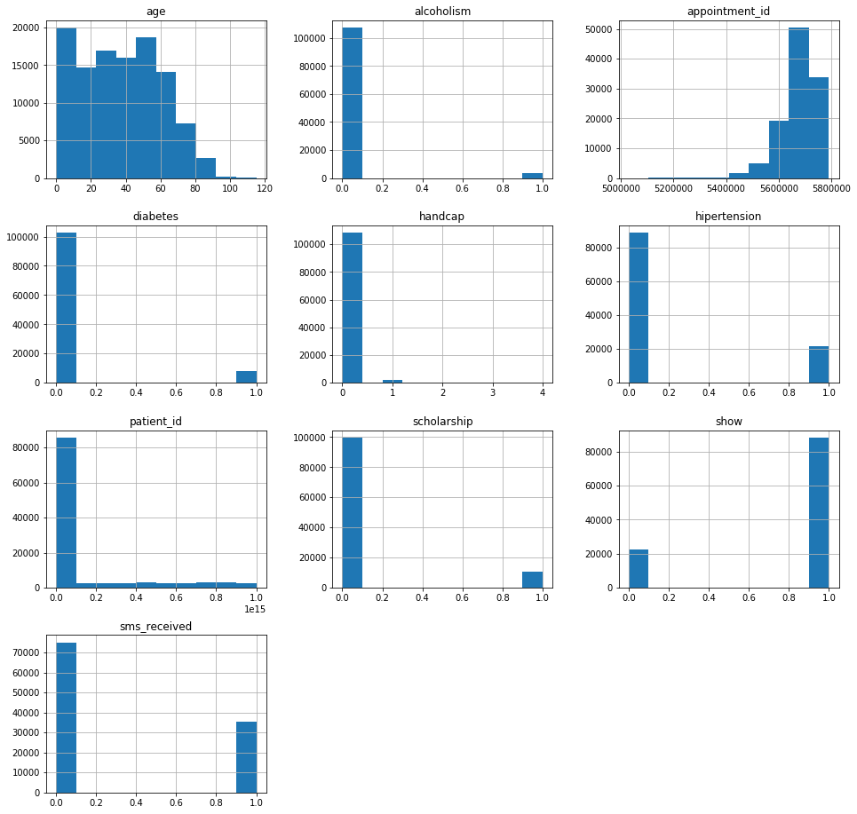

```python
df_app.hist(figsize=(16,16));
```

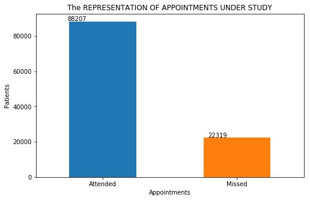

```python
# checking appointments attendance frequency

ax = df_app.show.value_counts().plot(kind='bar',figsize=(8,5),title="The REPRESENTATION OF APPOINTMENTS UNDER STUDY"
                                    )
ax.set_xlabel("Appointments")
ax.set_ylabel("Patients")
ax.set_xticklabels(['Attended','Missed'],rotation=0)

for p in ax.patches:
    ax.annotate(str(p.get_height()), (p.get_x() * 1.045, p.get_height() * 1.005))
```

As clearly shown in the figure above, we have more people showing up for the appointment than missed, with 88207 showing up for appointments and 22319 missing their appointments. lets proceed to categories based on the age distribution categories by [Research Gate](https://www.researchgate.net/figure/Age-intervals-and-age-groups_tbl1_228404297)

### AGE DISTRIBUTION OF KEEPING TO APPOINTMENT AND MISSING APPOINTMENT

We would be initializing our patients based on showing and missing appointment for easy calling with respect to keeping up with appointment. Afterwards we would categorize our age feature to get a better reflection through grouping using pd.cut function in this section codes below.

```python
''' Initializing our showing to appointment series
so we can have a proper representation of missed and keeping to appointment in our investigative analysis  '''

df_showed = df_app.show == True #Kept appointment
df_missed = df_app.show == False #Missed appointment

# categorising using pd.cut() function
bin_edges = [0,3,39,59,99,115]
bin_labels = ["Infant","Young_Adults","Middle-aged_Adults","Old_Adults","Aged_Adults"]
df_app["age_category"] = pd.cut(df_app.age,bins=bin_edges,labels=bin_labels,include_lowest=True)
```

```python
# Extracting values for show in respect to Age
pd.DataFrame(df_app.groupby(["age_category"])["show"].describe().loc[:,['mean','std']])
```

| age_category | mean | std |
| --- | --- | --- |
| Infant | 0.822990 | 0.381698 |
| Young_Adults | 0.764830 | 0.424109 |
| Middle-aged_Adults | 0.811918 | 0.390784 |
| Old_Adults | 0.846943 | 0.360051 |
| Aged_Adults | 0.727273 | 0.467099 |

```python
df_app[df_showed].groupby(['age_category'])['show'].value_counts()
```

```
age_category        show
Infant              1        7360
Young_Adults        1       38500
Middle-aged_Adults  1       24416
Old_Adults          1       17923
Aged_Adults         1           8
Name: show, dtype: int64
```

```python
df_app[df_missed].groupby(['age_category'])['show'].value_counts()
```

```
age_category        show
Infant              0        1583
Young_Adults        0       11838
Middle-aged_Adults  0        5656
Old_Adults          0        3239
Aged_Adults         0           3
Name: show, dtype: int64
```

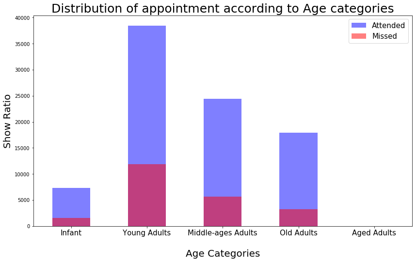

```python
# plotting the age distribution

df_app[df_showed].groupby(['age_category'])['show'].value_counts().plot(kind="bar",alpha = 0.5,figsize=(14,8),color='blue');
df_app[df_missed].groupby(['age_category'])['show'].value_counts().plot(kind="bar", alpha = 0.5,figsize=(14,8),color="red");
plt.xticks([0,1,2,3,4],['Infant','Young Adults', 'Middle-ages Adults','Old Adults','Aged Adults'],fontsize=15, rotation=0);
plt.title('Distribution of appointment according to Age categories',fontsize=25);
plt.ylabel('Show Ratio',fontsize=20);
plt.xlabel('\nAge Categories',fontsize=20);
plt.legend(['Attended','Missed'],fontsize=15);
```

There are more young adults of age (3 - 39) years turning out for appointment than any other age group as classified in the graph above. The Age adults seems not to appear on the on the graph due to the number of patients in that category compared to other categories is infinitesimal.

### GENDER DISTRIBUTION OF KEEPING TO APPOINTMENT AND MISSING APPOINTMENT

```python
# Extracting value for show in respect to Gender
Gender_dist = df_app.groupby("gender")['show'].value_counts()
Gender_dist
```

```
gender  show
F       1       57245
        0       14594
M       1       30962
        0        7725
Name: show, dtype: int64
```

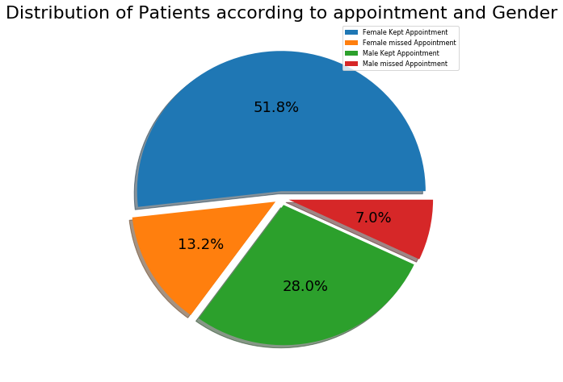

```python
# Gender plotting
Gender_dist.plot(kind="pie",figsize=(8,8),autopct = '%1.1f%%',shadow = True, explode= [0.05, 0.05,0.05,0.05],
  labels=None,fontsize=18);
x= ['Female Kept Appointment','Female missed Appointment','Male Kept Appointment','Male missed Appointment']
plt.legend(bbox_to_anchor=(1, 1.02), loc='upper left');
plt.title("Distribution of Patients according to appointment and Gender",fontsize=22)
plt.legend(x,fontsize=8);
plt.ylabel(" ")

plt.show()
```

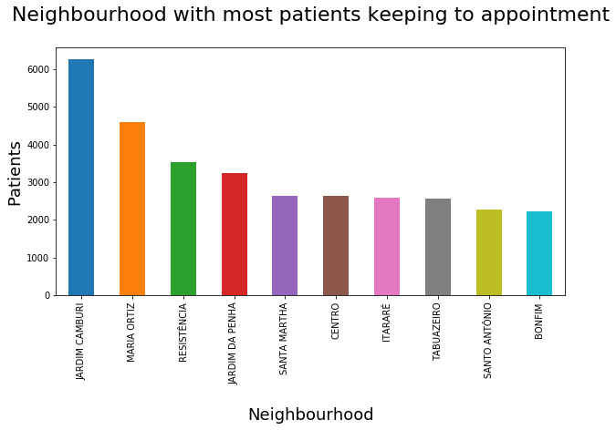

```python
def neigh_plot(y):
    # plotting for appointments with respect to Neighourhood
    df_app[y].neighbourhood.value_counts().head(10).plot(kind="bar",figsize=(10,5)); # plotting for the first 10 topmost neighbourhood
    if (y == df_showed).any():
        plt.title("Neighbourhood with most patients keeping to appointment\n",fontsize=22);
    else:
        plt.title("Neighbourhood with most patients missing appointment\n",fontsize=22);
    plt.ylabel("Patients",fontsize=18);
    plt.xlabel("\nNeighbourhood",fontsize=18);

neigh_plot(df_showed)
```

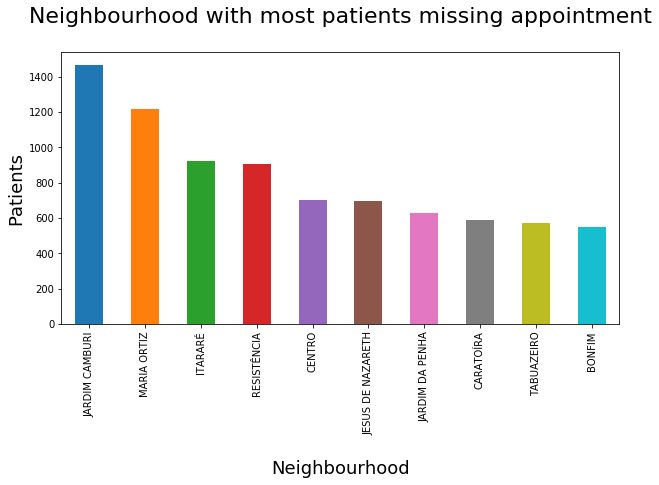

```python
neigh_plot(df_missed)
```

It appears the **JARDIM CAMBURI** appears to have both the highest patients keeping to appointments and highest missing appointments. let further investigate this neighbourhood to see what's peculiar in it.

```python
df_app.query("neighbourhood == 'JARDIM CAMBURI'").describe()
```

|  | patient_id | appointment_id | age | scholarship | hipertension | diabetes | alcoholism | handcap | sms_received | show |
| --- | --- | --- | --- | --- | --- | --- | --- | --- | --- | --- |
| count | 7.717000e+03 | 7.717000e+03 | 7717.000000 | 7717.000000 | 7717.000000 | 7717.000000 | 7717.000000 | 7717.000000 | 7717.000000 | 7717.000000 |
| mean | 1.451883e+14 | 5.644987e+06 | 43.731502 | 0.020604 | 0.065958 | 0.032526 | 0.001296 | 0.000778 | 0.333679 | 0.810159 |
| std | 2.540054e+14 | 1.084205e+05 | 22.537394 | 0.142063 | 0.248225 | 0.177403 | 0.035977 | 0.027875 | 0.471557 | 0.392200 |
| min | 2.157787e+08 | 5.280003e+06 | 0.000000 | 0.000000 | 0.000000 | 0.000000 | 0.000000 | 0.000000 | 0.000000 | 0.000000 |
| 25% | 3.699824e+12 | 5.582876e+06 | 27.000000 | 0.000000 | 0.000000 | 0.000000 | 0.000000 | 0.000000 | 0.000000 | 1.000000 |
| 50% | 3.275964e+13 | 5.675796e+06 | 49.000000 | 0.000000 | 0.000000 | 0.000000 | 0.000000 | 0.000000 | 0.000000 | 1.000000 |
| 75% | 9.434619e+13 | 5.722856e+06 | 61.000000 | 0.000000 | 0.000000 | 0.000000 | 0.000000 | 0.000000 | 1.000000 | 1.000000 |
| max | 9.999686e+14 | 5.790484e+06 | 97.000000 | 1.000000 | 1.000000 | 1.000000 | 1.000000 | 1.000000 | 1.000000 | 1.000000 |

On a total, there are total of 7717 patients alone making 7% of the total dataset been investigated. On average, there are of ages of 44years and there are high tendencies of attendance from this neighbourhood with attendance rate 81% on average.

### Research Question 3 (Which sickness are predominant in people missing or keeping up with appointment?)

```python
# Extracting sickness columns and appointment dates.

df_sickness = df_app.iloc[:,np.r_ [4,8:12]]
df_sickness.head()
```

|  | appointment_day | hipertension | diabetes | alcoholism | handcap |
| --- | --- | --- | --- | --- | --- |
| 0 | 2016-04-29 | 1 | 0 | 0 | 0 |
| 1 | 2016-04-29 | 0 | 0 | 0 | 0 |
| 2 | 2016-04-29 | 0 | 0 | 0 | 0 |
| 3 | 2016-04-29 | 0 | 0 | 0 | 0 |
| 4 | 2016-04-29 | 1 | 1 | 0 | 0 |

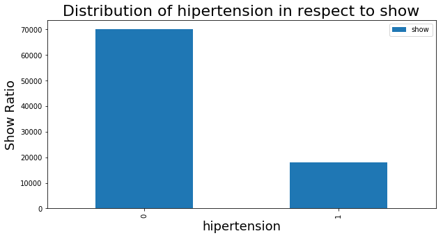

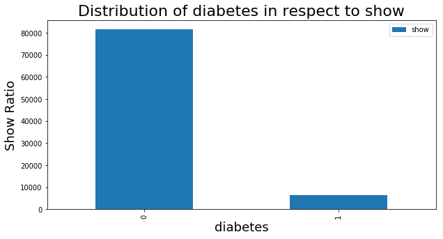

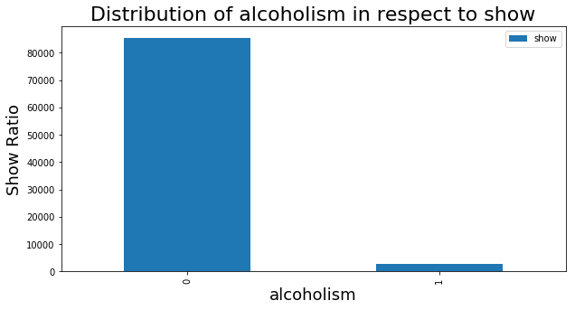

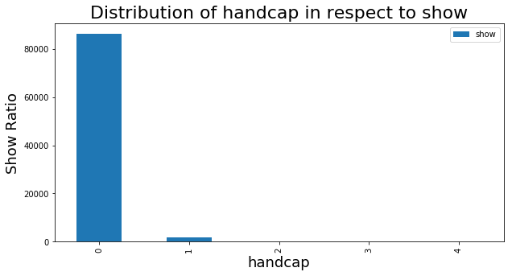

```python
#let's consider generally, the sickness in relation to the show appointment turn out.
def sick_plot():
    sickness = ['hipertension','diabetes','alcoholism','handcap']
    for i in sickness:
        df_app.groupby([i])[['show']].sum().plot(kind="bar",figsize=(10,5)).set_ylabel("Show Ratio",fontsize=18);
        plt.xlabel(i,fontsize=18)
        plt.title(f"Distribution of {i} in respect to show",fontsize=22);

sick_plot()
```

let's get the average of the sickness series with respect to missing and keeping to appointment

```python
# Sickness distribution by average in respect to keeping to appointment.
df_sickness[df_showed].mean()
```

```
hipertension    0.204394
diabetes        0.073838
alcoholism      0.030417
handcap         0.022742
dtype: float64
```

```python
#Sickness distribution by average in respect to missing appointment.
df_sickness[df_missed].mean()
```

```
hipertension    0.169004
diabetes        0.064071
alcoholism      0.030333
handcap         0.020297
dtype: float64
```

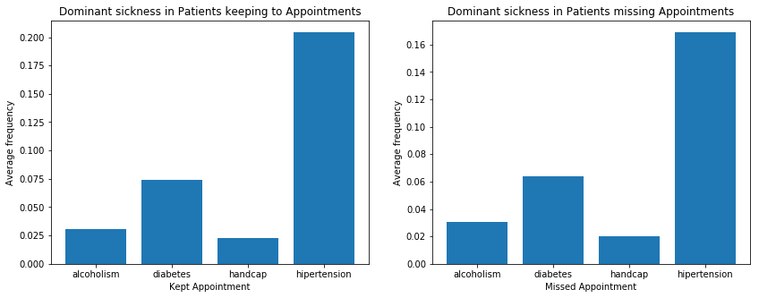

```python
plt.figure(figsize=(14,5))

x = df_sickness.columns[1:]

#plotting for showed to appointment
plt.subplot(1,2,1)
plt.bar(x,df_sickness[df_showed].mean())
plt.ylabel('Average frequency')
plt.xlabel('Kept Appointment')
plt.title("Dominant sickness in Patients keeping to Appointments")

#plotting for missed appointment
plt.subplot(1,2,2)
plt.bar(x,df_sickness[df_missed].mean())
plt.ylabel('Average frequency')
plt.xlabel('Missed Appointment')
plt.title("Dominant sickness in Patients missing Appointments")

plt.show()
```

Hipertension appears to be dorminant amongst the patients of our appointment study investigation followed by diabetes as shown in the bar plots above. The least is handcap in both patients keeping up to appointments and missing appointments.

### Research Question 4 ( What factors are important for us to know in order to predict if a patient will show up for their scheduled appointment (x = scholarship, sms. y = show-appointment?)

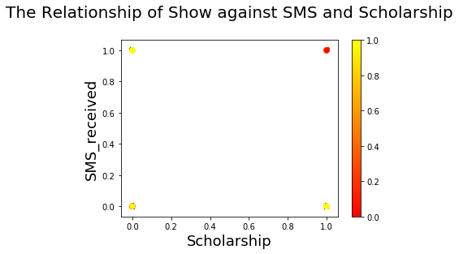

```python
# checking the relationship between Show against scholarship and sms.
plt.scatter(df_app.scholarship, df_app.sms_received, c = df_app['show'], cmap = 'autumn')
plt.title("The Relationship of Show against SMS and Scholarship\n",fontsize=20)
plt.ylabel('SMS_received',fontsize=18)
plt.xlabel('Scholarship',fontsize=18)
plt.colorbar()
plt.show()
```